# Coursework 0 Notebook

Q1. Write code for log(PCB) against age, reproducing the final plot containing both the equation line and the data points.

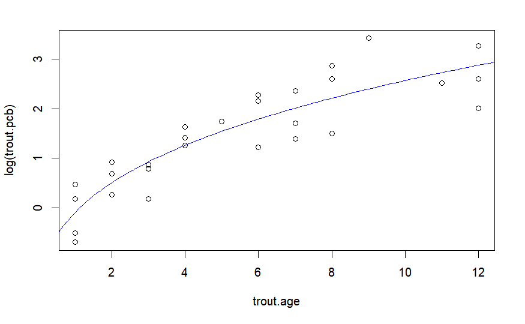

```r
#Task 1 - Reproducing the plot for age vs. log(PCB)
install.packages("formatR")
#library(formatR)

ages <- seq(from=0, to=13, by=0.1)
a <- -2.3907
b <- 2.300
l <- a + b*ages^(1/3)
trout.age <- c(1, 1, 1, 1, 2, 2, 2, 3, 3, 3, 4,4, 4, 5, 6, 6, 6, 7, 7, 7, 8, 8,
               8, 9, 11, 12, 12, 12)
trout.pcb <- c(0.6 , 1.6, 0.5, 1.2, 2.0, 1.3, 2.5,2.2, 2.4, 1.2, 3.5, 4.1, 5.1, 5.7,
               3.4, 9.7, 8.6, 4.0, 5.5, 10.5, 17.5,13.4, 4.5, 30.4, 12.4, 13.4, 26.2, 7.4)
plot(x=trout.age, y=log(trout.pcb))
lines(x=ages, y=l, type="l", col="blue")
```

Q2. Rewrite the log(PCB) equation as a function which has arguments; a, b, and age, and returns the predicted log(PCB).

```r
#Task 2 - Rewrite log(PCB) as a function

calc_PCB = function(a, b, age) {
  predicted_l <- a + b*age^(1/3)
  return (predicted_l)
}
#calc_PCB(a,b,ages)
```

Q3. By extending the range of age considered, produce a plot which shows the curve for the expected log(PCB) concentration for lake trout up to 20 years old.

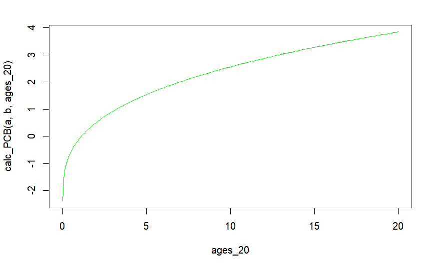

```r
#Task 3 - Extend ages to 20 years

ages_20 <- seq(from=0, to=20, by=0.1)
plot(x=ages_20, y=calc_PCB(a,b,ages_20), "l", col="green")
```

Q4. Now extract the maximum expected/predicted log(PCB) from the values used to draw the equation line

```r
#Task 4 - Get Maximum
#ages_20
#calc_PCB(a,b,ages_20)
max(calc_PCB(a,b,ages_20))
```

```
[1] 3.852461
```

Q5. It can be shown that a non-linear model of the form l = a + b × age^c where a, b, and c are constants provides a slightly better fit to the data. The optimal choices are a = −4.865, b = 4.7016, and c = 0.1969. (a) Rewrite the log(PCB) equation as a function which has arguments; a, b, c and age, and returns the predicted log(PCB). [1 mark] (b) Compare the Bates-Watts estimator and the new estimator for the expected log(PCB) concentration of a 10 year old lake trout. [1 mark] (c) Create a new plot which has both the old line and new line, allowing a comparison of the differences.

```r
#Task 5 - Non-linear model

a2 = -4.865
b2 = 4.7016
c2 = 0.1969

# Task 5.1 - Rewrite log equation function

calc_PCB2 = function(a,b,c,age) {
  predicted_l = a + b * (age^c)
  return (predicted_l)
}

# Task 5.2 - Compare
fixed_age = 10
calc_PCB(a,b,fixed_age)
```

```
[1] 2.5645
```

```r
calc_PCB2(a2,b2,c2,fixed_age)
```

```
[1] 2.533534
```

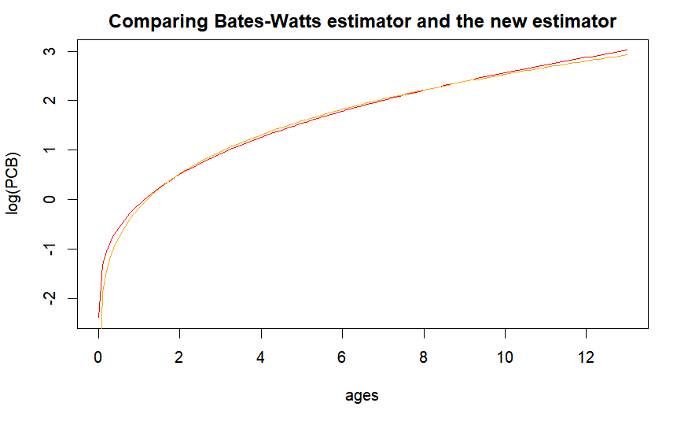

```r
# Task 5.3 - Plot both equations
plot(x=ages, y=l, type="l", col="red", ylab = "log(PCB)", main="Comparing Bates-Watts estimator and the new estimator")
lines(ages, calc_PCB2(a2,b2,c2,ages), type="l", col="orange")
```